# Figure2: Population genetics with adegenet

Aurora García-Berro

2024-10-15

```r
knitr::opts_chunk$set(echo = TRUE)
```

## Preparing data from ipyrad

First we want to sort the vcf file by sample ID in order to make it easier after to add population data. We do that by:

$ bcftools query -l data2_chr8_shortnames.vcf | sort > samples.txt $ bcftools view -S samples.txt data2_chr8_shortnames.vcf > data2_chr8_sorted.vcf

We removed sexual chromosomes and filtered by missing data. We will filter more with R.

$ vcftools –vcf data2_chr8_shortnames.vcf –max-missing 0.8 –mac 2 –recode –recode-INFO-all –stdout > data2_chr8_md80.vcf

We need our file in a genind object, which is the object used within adegenet package. We can import the vcf file using the functions read.vcfR() and vcfR2genind() from the library vcfR.

```r
library(adegenet)
library(vcfR)
# Read your dataset in genepop and convert it to genind.
vcf <- read.vcfR(file = "/home/aurora/IBB/Migratory_divide/pca/dataset1_only_inversion.vcf", verbose = TRUE)
```

```
## Scanning file to determine attributes.
## File attributes:
##   meta lines: 48
##   header_line: 49
##   variant count: 976
##   column count: 302
##
Meta line 48 read in.
## All meta lines processed.
## gt matrix initialized.
## Character matrix gt created.
##   Character matrix gt rows: 976
##   Character matrix gt cols: 302
##   skip: 0
##   nrows: 976
##   row_num: 0
##
Processed variant: 976
## All variants processed
```

```r
x <- vcfR2genind(vcf)
```

Now we introduce population data:

```r
# 293 samples (- Namibia2,9,12,14,13,7 Ethiopia34 were removed due to high relatedness)
# Middle are individuals detected as heterozygous. The first time I run this pipeline ony had North and South groups

populations <- c("North","North","North","North","North","North","North","North","South","South","South","South","South","South","South","South","Middle","South","South","South","South","South","South","South","South","North","North","North","North","North","North","North","North","North","North","North","North","North","North","North","North","North","North","North","South","North","North","South","Middle","North","North","North","North","North","North","North","North","North","North","North","North","North","North","North","North","North","Middle","Middle","North","North","North","North","North","North","North","North","North","South","South","South","South","Middle","Middle","North","North","North","North","North","North","North","North","North","North","North","North","North","North","North","North","North","North","North","North","North","North","North","North","North","North","North","North","North","North","North","North","North","North","North","North","North","North","North","North","North","North","North","North","North","North","North","North","North","North","North","North","North","North","North","North","North","North","North","North","North","North","North","North","North","North","North","North","North","North","North","North","North","North","North","North","North","North","North","North","North","North","Middle","North","North","North","North","North","Middle","North","North","North","North","North","North","North","North","North","North","North","North","North","North","North","North","South","South","South","South","South","Middle","South","South","South","South","South","South","South","South","South","South","South","South","South","South","South","Middle","South","South","South","North","North","North","North","North","North","North","North","North","North","North","North","North","North","North","North","North","North","North","North","North","North","North","North","North","North","North","North","North","North","North","North","North","North","North","North","North","Middle","North","North","North","Middle","Middle","North","North","North","North","North","North","North","North","North","North","North","North","North","North","North","North","North","North","North","North","North","North","North","North","North","North","North","North","North","North","North","North","North","North","Middle","Middle","South")
pop(x) <- populations
```

Now we check how many individuals a loci has.

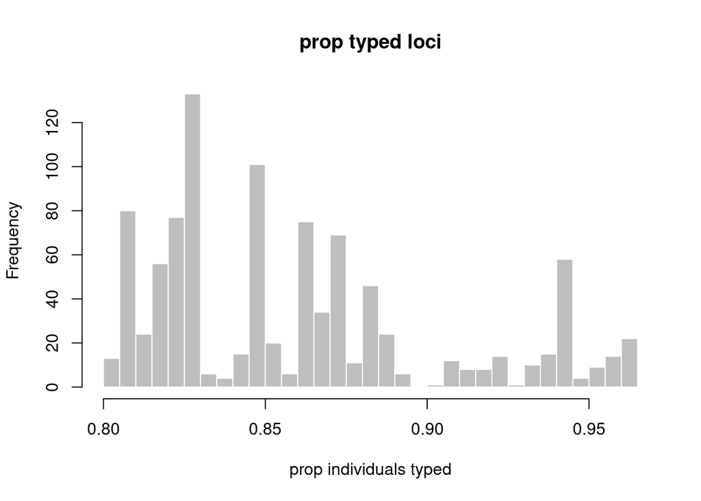

```r
prop_typed_loc <- propTyped(x, "loc") # et diu els individus que té cada loci
hist(prop_typed_loc, col = "grey", border = "white", nclass = 30,
     main = "prop typed loci", xlab = "prop individuals typed")
```

We can also filter by individuals, knowing the proportion of loci that each individual has using the function proptyped.

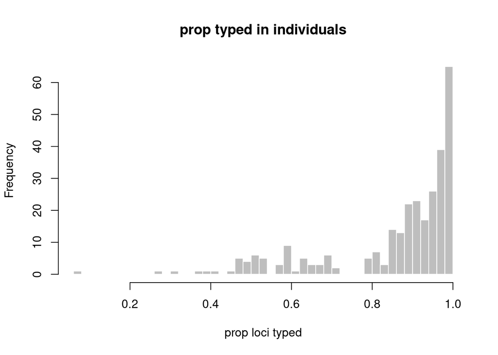

```r
prop_typed_ind <- propTyped(x) # proptyped funció que diu proporció loci té cada indv
hist(prop_typed_ind, col = "grey", border = "white", nclass = 40,
     main = "prop typed in individuals", xlab = "prop loci typed")
```

We can check how many individuals we have before…

```r
x
```

```
## /// GENIND OBJECT /////////
##
##  // 293 individuals; 976 loci; 2,035 alleles; size: 2.9 Mb
##
##  // Basic content
##    @tab:  293 x 2035 matrix of allele counts
##    @loc.n.all: number of alleles per locus (range: 2-4)
##    @loc.fac: locus factor for the 2035 columns of @tab
##    @all.names: list of allele names for each locus
##    @ploidy: ploidy of each individual  (range: 2-2)
##    @type:  codom
##    @call: adegenet::df2genind(X = t(x), sep = sep)
##
##  // Optional content
##    @pop: population of each individual (group size range: 15-232)
```

… and after filtering.

```r
IND_THRESHOLD <- 0.4
y <- x[prop_typed_ind > IND_THRESHOLD]
y
```

```
## /// GENIND OBJECT /////////
##
##  // 288 individuals; 976 loci; 2,035 alleles; size: 2.8 Mb
##
##  // Basic content
##    @tab:  288 x 2035 matrix of allele counts
##    @loc.n.all: number of alleles per locus (range: 2-4)
##    @loc.fac: locus factor for the 2035 columns of @tab
##    @all.names: list of allele names for each locus
##    @ploidy: ploidy of each individual  (range: 2-2)
##    @type:  codom
##    @call: .local(x = x, i = i, j = j, drop = drop)
##
##  // Optional content
##    @pop: population of each individual (group size range: 15-227)
```

Which samples were removed?

```r
samplenames <- indNames(y)
length(samplenames)
```

```
## [1] 288
```

```r
samplenames_before <- indNames(x)
length(samplenames_before)
```

```
## [1] 293
```

```r
diff <- unique(samplenames_before[! samplenames_before %in% samplenames])
diff
```

```
## [1] "Algeria1"   "Algeria5"   "Algeria6"   "Ethiopia31" "Russia1"
```

## PCA

For a pca we have to select number of principal components we retain in the option “nf”.

```r
x <- y # the rest of the code is using "x"
x.nomd <- tab(x, freq=TRUE, NA.method="mean")
pca.x <- dudi.pca(df = x.nomd, center = TRUE, scale = FALSE, scannf = FALSE, nf = 5)
pca.x
```

```
## Duality diagramm
## class: pca dudi
## $call: dudi.pca(df = x.nomd, center = TRUE, scale = FALSE, scannf = FALSE,
##     nf = 5)
##
## $nf: 5 axis-components saved
## $rank: 287
## eigen values: 16.26 1.512 1.221 1.072 0.8815 ...
##   vector length mode    content
## 1 $cw    2035   numeric column weights
## 2 $lw    288    numeric row weights
## 3 $eig   287    numeric eigen values
##
##   data.frame nrow ncol content
## 1 $tab       288  2035 modified array
## 2 $li        288  5    row coordinates
## 3 $l1        288  5    row normed scores
## 4 $co        2035 5    column coordinates
## 5 $c1        2035 5    column normed scores
## other elements: cent norm
```

```r
write.csv(pca.x$li, "/home/aurora/IBB/Migratory_divide/pca/eigenvalues_293_chr8.csv", row.names = TRUE)
```

We can now plot it using labels for each sample.

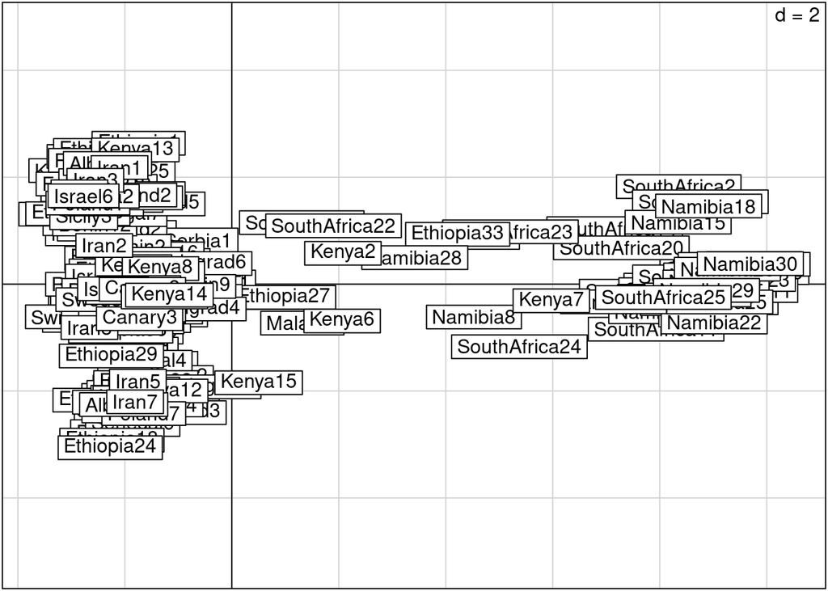

```r
s.label(pca.x$li)
```

We can avoid labels to overlap by using wordcloud.

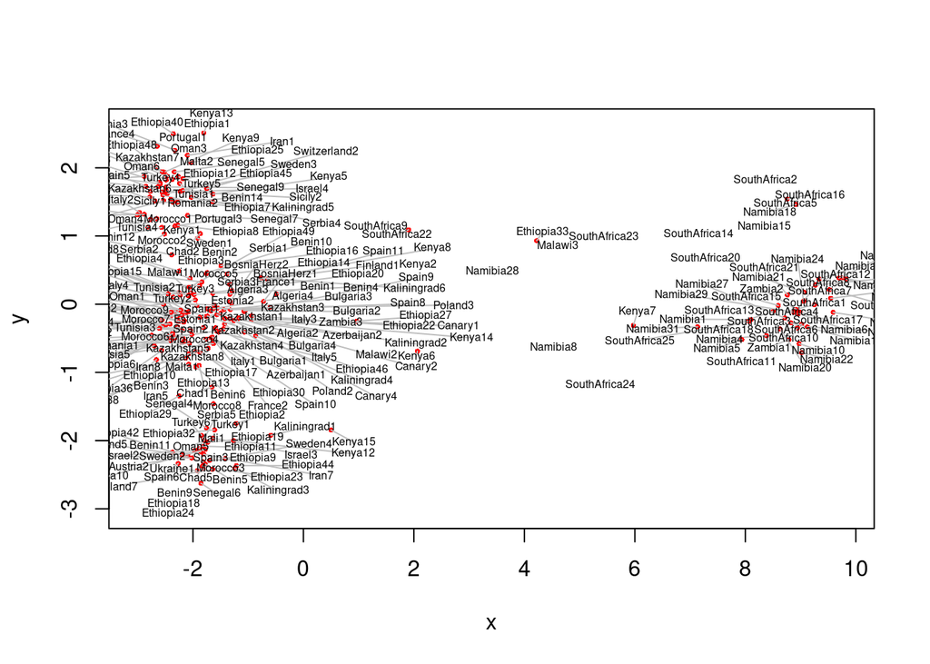

```r
library(wordcloud)
textplot(pca.x$li[,1], pca.x$li[,2], words=rownames(pca.x$li),cex=0.5)
```

A nicer PCA:

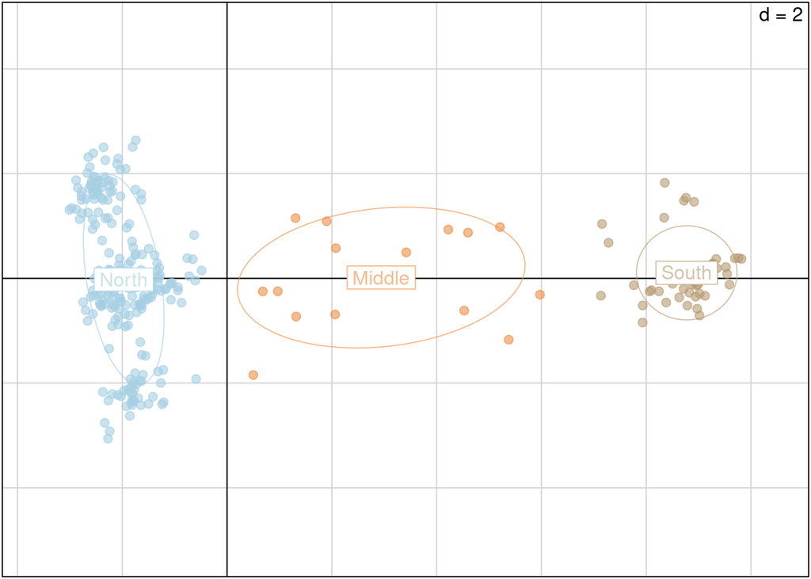

```r
s.class(pca.x$li, fac=pop(x),
        col=transp(funky(4),.6),
        axesel=FALSE, cstar=0, cpoint=1.5, grid = TRUE
        )
```

Let’s us examine the contribution of each eigenvalue.

```r
eig.perc <- 100*pca.x$eig/sum(pca.x$eig)
head(eig.perc)
```

```
## [1] 36.405073  3.385365  2.733660  2.399754  1.973531  1.783849
```

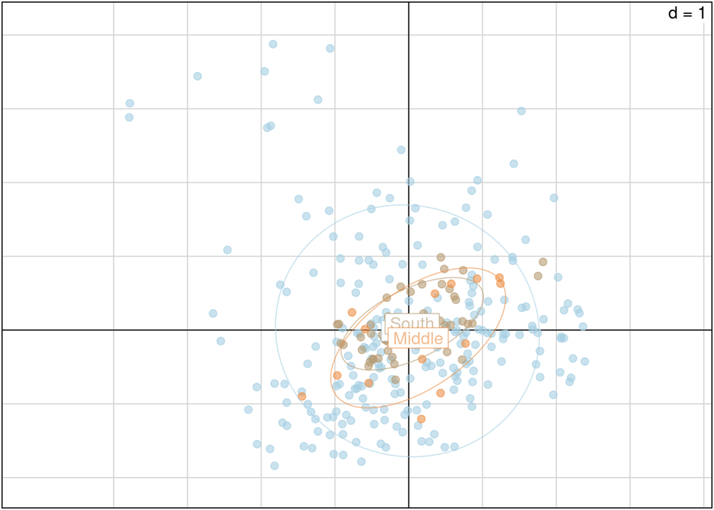

```r
s.class(pca.x$li, fac=pop(x),
        xax=3, yax=4,
        col=transp(funky(4),.6),
        axesel=FALSE, cstar=0, cpoint=1.5)
```

These are the sample names of the potential heterozygous:

```r
library ("dplyr")
# let's extract samples between PC1 values of 0 and 6
pca.coord <- pca.x$li
pca.coord.0 <- filter(pca.coord, Axis1>0)
pca.coord.0 <- pca.coord.0[order(pca.coord.0$Axis1),]
pca.coord.06 <- filter(pca.coord.0, Axis1<6)

het <- row.names(pca.coord.06)
write(het, "het.txt")
# Kenya15,Zambia3,Ethiopia27,SouthAfrica9,Malawi2,SouthAfrica22,Kenya6,Kenya2,Namibia28,Ethiopia33,Namibia8,Malawi3,SouthAfrica23,SouthAfrica24,Kenya7
```

## Allele contributions

Allele contributions can sometimes be informative. A way to capture this is to use loadings. It is important to realize that the principal components are less interpretable and don’t have any real meaning since they are constructed as linear combinations of the initial variables. But we can analyze the loadings which describe the importance of the independent variables. The loadings are from a numerical point of view, equal to the coefficients of the variables, and provide information about which variables give the largest contribution to the components. Source: https://towardsdatascience.com/what-are-pca-loadings-and-biplots-9a7897f2e559

- Loadings range from -1 to 1.
- A high absolute value (towards 1 or -1) describes that the variable strongly influences the component. Values close to 0 indicate that the variable has a weak influence on the component.
- The sign of a loading (+ or -) indicates whether a variable and a principal component are positively or negatively correlated.

A basic graphic for representing allele loadings is s.arrow. It represents the results of the PCA (pca.x$c1).

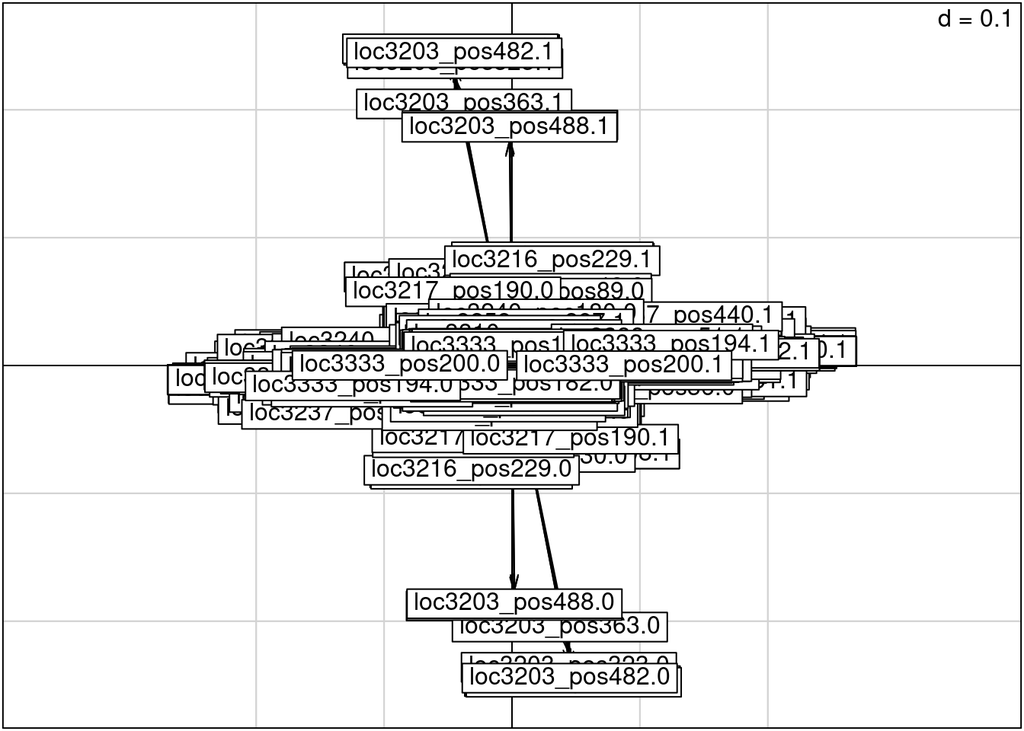

```r
s.arrow(pca.x$c1)
```

We can also represent loadings by using loadingplot, which represents one axis at a time. The loadingplot function simply represents positive values of a vector and identifies the values above a given threshold.

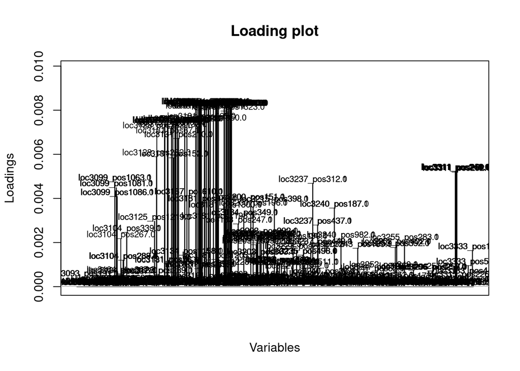

```r
loadingplot(pca.x$c1^2)
```